# Oman 2019 taxa table analysis

Source file: OM19_taxa_table_analysis.Rmd

Daniel Nothaft

2020-05-26

# Setup

## Load packages

```r
library(mctoolsr) # working with taxonomic data
library(tidyverse) # working with data frames
library(knitr) # printing things nicely

# global knitting options for automatic saving of all plots as .png and .pdf. Also sets cache directory.
knitr::opts_chunk$set(
  dev = c("png", "pdf"), fig.keep = "all",
  dev.args = list(pdf = list(encoding = "WinAnsi", useDingbats = FALSE)),
  fig.path = file.path("fig_output/", paste0(gsub("\\.[Rr]md", "/", knitr::current_input()))),
  cache.path = file.path("cache/", paste0(gsub("\\.[Rr]md", "/", knitr::current_input())))
)
```

## Load in map file and otutable

```r
tax_table_fp <- 'data_output/20200526_tax_tab_DADA2_mctoolsr_OM19_Silva138_Bayes_packers.txt'
map_fp <- 'data_raw/Summary_metadata/meta_map_16S_OM19_packers.txt'
input <- load_taxa_table(tax_table_fp, map_fp) #combine data to format for mctoolsr
```

```
## 6 samples loaded
```

# Overall trends and data curation

## look at reads per sample

Samples have more reads than the blank (at minimum 20X more reads), which is good.

Show read counts

```r
sort(colSums(input$data_loaded))
```

```
## Blank   D45  D102   A41   A30  A108
##    92 26524 41454 61900 65379 83732
```

Plot read counts

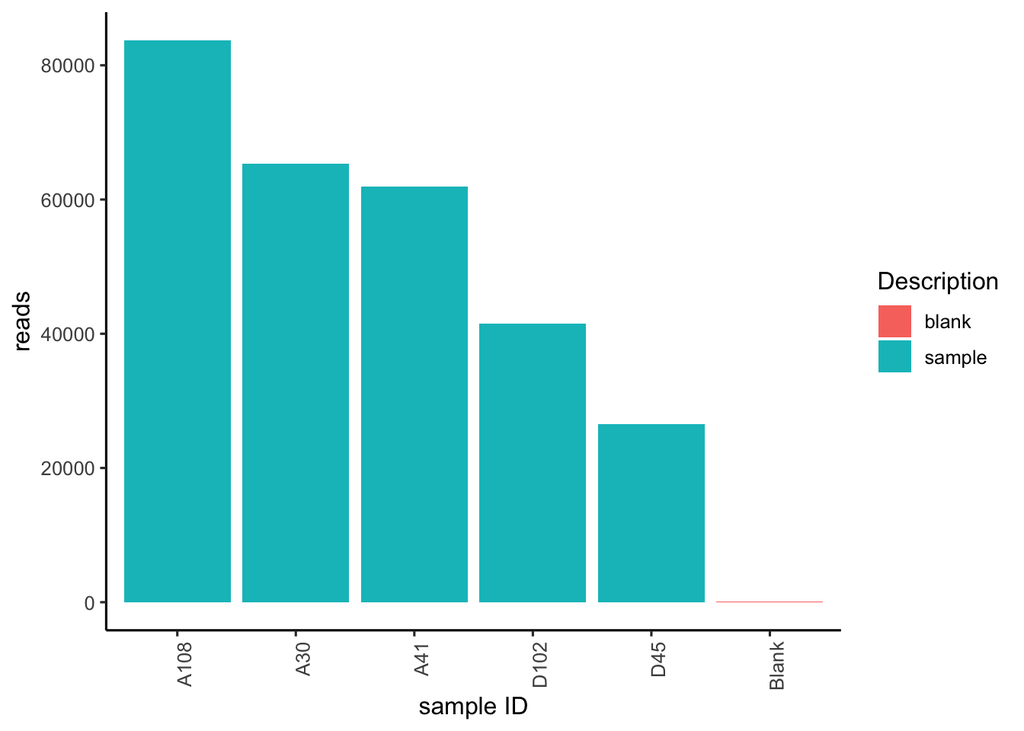

```r
# pull out metadata map
map <- input$map_loaded

# create data frame of reads
reads_per_sample_sums <- as.data.frame(colSums(input$data_loaded))

# create data frame of names of sample
reads_per_sample_names <- as.data.frame(colnames(input$data_loaded))

# combine reads with names to data frame of reads per sample
reads_per_sample <- cbind(reads_per_sample_sums, reads_per_sample_names)

# rename columns with more descriptive names
reads_per_sample <- rename(reads_per_sample, reads = "colSums(input$data_loaded)", sample_ID = "colnames(input$data_loaded)")

# add metadata
reads_per_sample <- left_join(reads_per_sample, map, by = "sample_ID") %>% select(sample_ID, reads, Description)

# create plot
read_tally <- reads_per_sample %>% ggplot(

  # plot data
  aes(x = reorder(sample_ID, -reads),
      y = reads,
      fill = Description)) +
  geom_bar(stat = "identity") +

  # axis styling
  scale_x_discrete(name = "sample ID") +

  # design
  theme_classic(base_size = 12) +
  theme(
    axis.text.x = element_text(angle = 90, hjust = 1))

# print plot
read_tally
```

## Filter out mitochondria, chloroplasts, eurkaryotes, and sequences not assigned taxonomy at the the domain level

```r
# Chloroplast not in dataset
input_filt <- filter_taxa_from_input(input, taxa_to_remove = c("Mitochondria", "Eukaryota"))
```

```
## 5 taxa removed
```

```r
# input_filt <- filter_taxa_from_input(input_filt, at_spec_level = 1, taxa_to_remove = "NA") # no taxa not assigned at domain level in this dataset
```

Show read counts of filtered data

```r
sort(colSums(input_filt$data_loaded))
```

```
## Blank   D45  D102   A41   A30  A108
##    92 26517 41454 61889 65376 83718
```

## Focus on samples

```r
# select desired samples
Oman_samples <- input_filt %>% filter_data(filter_cat = "sample_ID", filter_vals = c("Blank"))
```

```
## 5 samples remaining
```

Rarefy to lowest read count among samples

```r
Oman_samples = single_rarefy(Oman_samples, min(sort(colSums(Oman_samples$data_loaded))))
```

```
## 5 samples remaining
```

```r
# extract metadata for desired samples
map_Oman_samples <- Oman_samples$map_loaded
```

# Taxonomic overview

Summarize taxonomy at species level

```r
# summarize taxonomic classification at species level
Oman_samples_sum <- summarize_taxonomy(Oman_samples, level = 7, report_higher_tax = TRUE)
```

Generate heat map

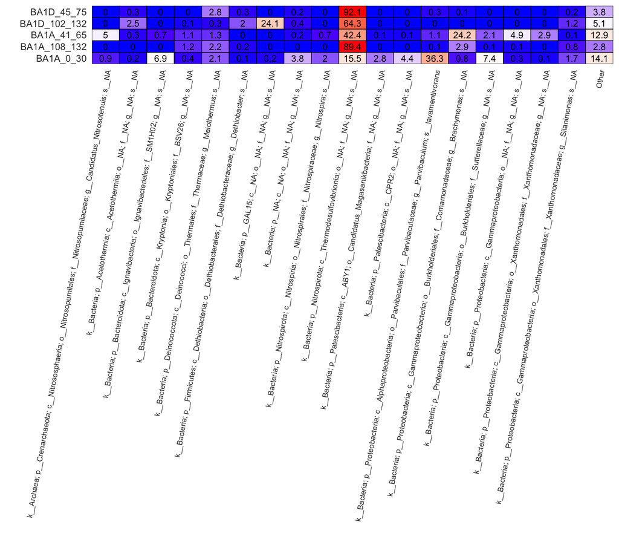

```r
Oman_samples_sum_higher_plot <- plot_ts_heatmap(Oman_samples_sum, map_Oman_samples, 0.005,  "well")

Oman_samples_sum_higher_plot +
  theme(axis.text.x = element_text(angle = 80, hjust = 1, vjust = 1, size = 7))
```

# CH$_4$-cycling taxa

## Sort data

### list taxa of interest

```r
# input methane cycle
all_methane_taxa_oman <- c("Methanobacteria", "Methanomicrobia", "Methanopyrales", "Methanocellales", "Methanoplasmatales", "Methanosarcinales", "Methanomassiliicocc", "Methylococc", "Methylocystis", "Methylosinus", "Methylocella", "Methylocapsa", "Methylacidiphil", "Methylomirabilis", "ANME")
```

### filter for all CH$_4$-cycling taxa

```r
# filter for CH4-cycling taxa
Oman_samples_sum_all_methane_taxa <- filter_taxa_from_table(tax_table =  Oman_samples_sum, taxa_to_keep = all_methane_taxa_oman)

# get rownames of CH4 cycle taxa data frame
tax_long <- tibble(rownames(Oman_samples_sum_all_methane_taxa))
colnames(tax_long) <- "tax_long"

# Reshaping data so it is easier to work with

# make rownames into a column
Oman_samples_sum_all_methane_taxa <- bind_cols(tax_long, Oman_samples_sum_all_methane_taxa)

# print
Oman_samples_sum_all_methane_taxa
```

| tax_long | A108 | A30 | A41 | D102 | D45 |
| --- | --- | --- | --- | --- | --- |
| k__Archaea; p__Euryarchaeota; c__Methanobacteria; o__Methanobacteriales; f__Methanobacteriaceae; g__Methanobacterium; s__NA | 0 | 0 | 0 | 0.001772448 | 0 |

### show full taxonomy of CH$_4$-cycling taxa in easily searchable format

```r
# gather data
Oman_samples_sum_all_methane_taxa_long_gathered <- Oman_samples_sum_all_methane_taxa %>%  gather(key = "sample_ID", value = "rel_abund", -tax_long)

# pretty print
Oman_samples_sum_all_methane_taxa_long_gathered %>% kable()
```

| tax_long | sample_ID | rel_abund |
| --- | --- | --- |
| k__Archaea; p__Euryarchaeota; c__Methanobacteria; o__Methanobacteriales; f__Methanobacteriaceae; g__Methanobacterium; s__NA | A108 | 0.0000000 |
| k__Archaea; p__Euryarchaeota; c__Methanobacteria; o__Methanobacteriales; f__Methanobacteriaceae; g__Methanobacterium; s__NA | A30 | 0.0000000 |
| k__Archaea; p__Euryarchaeota; c__Methanobacteria; o__Methanobacteriales; f__Methanobacteriaceae; g__Methanobacterium; s__NA | A41 | 0.0000000 |
| k__Archaea; p__Euryarchaeota; c__Methanobacteria; o__Methanobacteriales; f__Methanobacteriaceae; g__Methanobacterium; s__NA | D102 | 0.0017724 |
| k__Archaea; p__Euryarchaeota; c__Methanobacteria; o__Methanobacteriales; f__Methanobacteriaceae; g__Methanobacterium; s__NA | D45 | 0.0000000 |

Add a shorthand name for taxa

```r
Oman_samples_sum_all_methane_taxa <- Oman_samples_sum_all_methane_taxa  %>% mutate(tax_short = case_when(
  tax_long == "k__Archaea; p__Euryarchaeota; c__Methanobacteria; o__Methanobacteriales; f__Methanobacteriaceae; g__Methanobacterium; s__NA" ~ "genus Methanobacterium",
    tax_long == "k__Bacteria; p__Proteobacteria; c__Gammaproteobacteria; o__Methylococcales; f__Methylococcaceae; g__Methylococcus; s__NA" ~ "genus Methylococcus"
))

# put into easily searchable format
Oman_samples_sum_all_methane_taxa_gathered <- Oman_samples_sum_all_methane_taxa %>% gather(key = "sample_ID", value = "rel_abund", -tax_short, -tax_long)

# pretty print
Oman_samples_sum_all_methane_taxa_gathered %>% select(-tax_long) %>% kable()
```

| tax_short | sample_ID | rel_abund |
| --- | --- | --- |
| genus Methanobacterium | A108 | 0.0000000 |
| genus Methanobacterium | A30 | 0.0000000 |
| genus Methanobacterium | A41 | 0.0000000 |
| genus Methanobacterium | D102 | 0.0017724 |
| genus Methanobacterium | D45 | 0.0000000 |

Add metadata map to gathered CH$_4$-cycling taxa data frame

```r
# join meta data map to CH4-cycling taxa data frame
gathered_w_map <- left_join(Oman_samples_sum_all_methane_taxa_gathered, map_Oman_samples, by = "sample_ID")
```

## Plot

### Prepare plot aesthetics

reorder factor levels so bar and legend plot in desired order

```r
gathered_w_map$tax_short <- factor(gathered_w_map$tax_short, levels = c(
  "genus Methylococcus",
  "genus Methanobacterium"))
```

Set fill colors for taxa

```r
# color-blind safe palette :
#F0E442 light yellow
#E69F00 mustard/gold
#D55E00 red
#CC79A7 magenta
#009E73 forest/mint green
#56B4E9 light blue
#0072B2 dark blue
#999999 grey
#000000 black

fill_taxa_named <- c(
  "genus Methylococcus" = "#E69F00",
  "genus Methanobacterium" = "#000000")
```

make formatting function to convert relative abundances to percent during plotting

```r
formatter100 <- function(x){
    x*100
}
```

### Plot

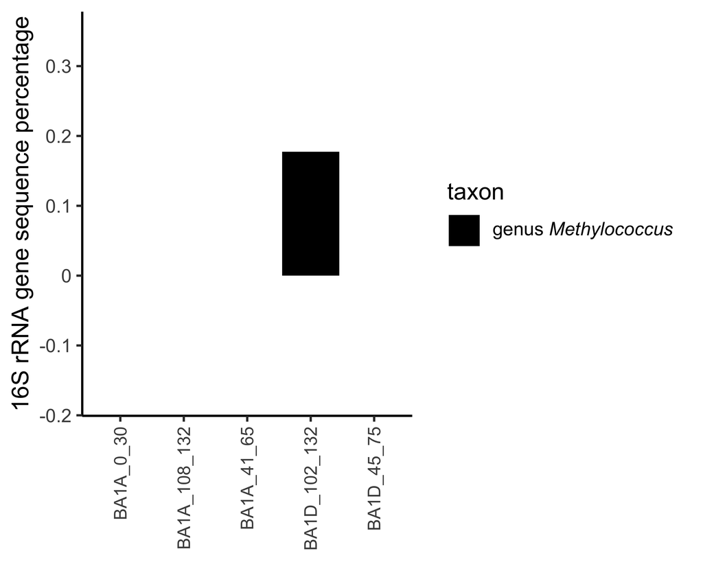

```r
# create plot
OM19_CH4_taxa_bar <- gathered_w_map %>% ggplot(

  # plot data
  aes(x = well,
      y = rel_abund,
      fill = tax_short)) +
  geom_bar(stat = "identity") +

  # axis styling
  scale_y_continuous(name = "16S rRNA gene sequence percentage", labels = formatter100, expand = c(0.004, 0.002))+
  scale_x_discrete(name = NULL)+

  # symbol styling
  scale_fill_manual(name = "taxon", values = fill_taxa_named, labels = unname(latex2exp::TeX(c("genus \\textit{Methylococcus}",
  "genus \\textit{Methanobacterium}")))) +

  # design
  theme_classic(base_size = 12)+
  theme(
    axis.text.x = element_text(angle = 90, hjust = 1, vjust = 0.5, size = 9),
    legend.direction = "vertical",
    legend.text.align = 0
)

# print
OM19_CH4_taxa_bar
```

# Hydrogenophaga

## Sort data

### list taxa of interest

```r
all_Hydrogenophaga_oman <- c("Hydrogenophaga")
```

### filter for all Hydrogenophaga

```r
# filter for Hydrogenophaga
Oman_samples_sum_all_Hydrogenophaga <- filter_taxa_from_table(tax_table =  Oman_samples_sum, taxa_to_keep = all_Hydrogenophaga_oman)

# get rownames of Hydrogenophaga data frame
tax_long <- tibble(rownames(Oman_samples_sum_all_Hydrogenophaga))
colnames(tax_long) <- "tax_long"

# Reshaping data so it is easier to work with

# make rownames into a column
Oman_samples_sum_all_Hydrogenophaga <- bind_cols(tax_long, Oman_samples_sum_all_Hydrogenophaga)

# print
Oman_samples_sum_all_Hydrogenophaga
```

| tax_long | A108 | A30 | A41 | D102 | D45 |
| --- | --- | --- | --- | --- | --- |
| k__Bacteria; p__Proteobacteria; c__Gammaproteobacteria; o__Burkholderiales; f__Comamonadaceae; g__Hydrogenophaga; s__aquatica | 0.00181016 | 0.0151978 | 0 | 0.0000000000 | 0.004713957 |
| k__Bacteria; p__Proteobacteria; c__Gammaproteobacteria; o__Burkholderiales; f__Comamonadaceae; g__Hydrogenophaga; s__NA | 0.00000000 | 0.0000000 | 0 | 0.0003394049 | 0.000000000 |

### show full taxonomy of Hydrogenophaga in easily searchable format

```r
# gather data
Oman_samples_sum_all_Hydrogenophaga_gathered <- Oman_samples_sum_all_Hydrogenophaga %>%  gather(key = "sample_ID", value = "rel_abund", -tax_long)

# pretty print
Oman_samples_sum_all_Hydrogenophaga_gathered %>% kable()
```

| tax_long | sample_ID | rel_abund |
| --- | --- | --- |
| k__Bacteria; p__Proteobacteria; c__Gammaproteobacteria; o__Burkholderiales; f__Comamonadaceae; g__Hydrogenophaga; s__aquatica | A108 | 0.0018102 |
| k__Bacteria; p__Proteobacteria; c__Gammaproteobacteria; o__Burkholderiales; f__Comamonadaceae; g__Hydrogenophaga; s__NA | A108 | 0.0000000 |
| k__Bacteria; p__Proteobacteria; c__Gammaproteobacteria; o__Burkholderiales; f__Comamonadaceae; g__Hydrogenophaga; s__aquatica | A30 | 0.0151978 |
| k__Bacteria; p__Proteobacteria; c__Gammaproteobacteria; o__Burkholderiales; f__Comamonadaceae; g__Hydrogenophaga; s__NA | A30 | 0.0000000 |
| k__Bacteria; p__Proteobacteria; c__Gammaproteobacteria; o__Burkholderiales; f__Comamonadaceae; g__Hydrogenophaga; s__aquatica | A41 | 0.0000000 |
| k__Bacteria; p__Proteobacteria; c__Gammaproteobacteria; o__Burkholderiales; f__Comamonadaceae; g__Hydrogenophaga; s__NA | A41 | 0.0000000 |
| k__Bacteria; p__Proteobacteria; c__Gammaproteobacteria; o__Burkholderiales; f__Comamonadaceae; g__Hydrogenophaga; s__aquatica | D102 | 0.0000000 |
| k__Bacteria; p__Proteobacteria; c__Gammaproteobacteria; o__Burkholderiales; f__Comamonadaceae; g__Hydrogenophaga; s__NA | D102 | 0.0003394 |
| k__Bacteria; p__Proteobacteria; c__Gammaproteobacteria; o__Burkholderiales; f__Comamonadaceae; g__Hydrogenophaga; s__aquatica | D45 | 0.0047140 |
| k__Bacteria; p__Proteobacteria; c__Gammaproteobacteria; o__Burkholderiales; f__Comamonadaceae; g__Hydrogenophaga; s__NA | D45 | 0.0000000 |

group taxa at genus level (Hydrogenophaga)

```r
# add grouped taxa name
Oman_samples_sum_all_Hydrogenophaga_grouped <- Oman_samples_sum_all_Hydrogenophaga %>% summarise_if(is.numeric, sum) %>% mutate(tax_group = "genus Hydrogenophaga")

Oman_samples_sum_all_Hydrogenophaga_grouped
```

| A108 | A30 | A41 | D102 | D45 | tax_group |
| --- | --- | --- | --- | --- | --- |
| 0.00181016 | 0.0151978 | 0 | 0.0003394049 | 0.004713957 | genus Hydrogenophaga |

### show Hydrogenophaga genus abundances in easily searchable format

```r
# gather genus-level Hydrogenophaga data frame
Oman_samples_sum_all_Hydrogenophaga_grouped_gathered <- Oman_samples_sum_all_Hydrogenophaga_grouped %>%  gather(key = "sample_ID", value = "rel_abund", -tax_group)

# pretty print
Oman_samples_sum_all_Hydrogenophaga_grouped_gathered %>% kable()
```

| tax_group | sample_ID | rel_abund |
| --- | --- | --- |
| genus Hydrogenophaga | A108 | 0.0018102 |
| genus Hydrogenophaga | A30 | 0.0151978 |
| genus Hydrogenophaga | A41 | 0.0000000 |
| genus Hydrogenophaga | D102 | 0.0003394 |
| genus Hydrogenophaga | D45 | 0.0047140 |

## Plot

### Prepare plot aesthetics

Add metadata

```r
# add metadata
gathered_grouped_w_map_Hydrogenophaga <- left_join(Oman_samples_sum_all_Hydrogenophaga_grouped_gathered, map_Oman_samples, by = "sample_ID")

# print
gathered_grouped_w_map_Hydrogenophaga
```

| tax_group | sample_ID | rel_abund | Description | well |
| --- | --- | --- | --- | --- |
| genus Hydrogenophaga | A108 | 0.0018101595 | sample | BA1A_108_132 |
| genus Hydrogenophaga | A30 | 0.0151977976 | sample | BA1A_0_30 |
| genus Hydrogenophaga | A41 | 0.0000000000 | sample | BA1A_41_65 |
| genus Hydrogenophaga | D102 | 0.0003394049 | sample | BA1D_102_132 |
| genus Hydrogenophaga | D45 | 0.0047139571 | sample | BA1D_45_75 |

### Plot

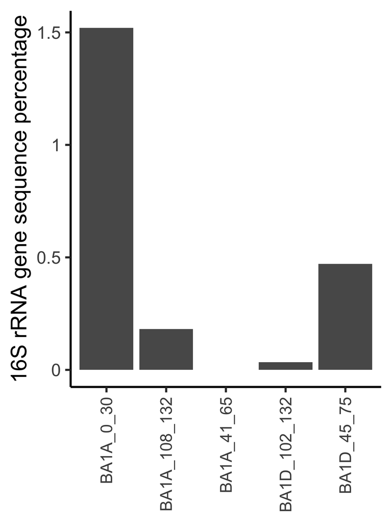

```r
# create plot
OM19_Hydrogenophaga_bar <- gathered_grouped_w_map_Hydrogenophaga %>% ggplot(

  # plot data
  aes(x = well,
      y = rel_abund)) +
  geom_bar(stat = "identity") +

  # axis styling
  scale_y_continuous(name = "16S rRNA gene sequence percentage", labels = formatter100)+
  scale_x_discrete(name = NULL)+

  # design
  theme_classic(base_size = 12)+
  theme(
    axis.text.x = element_text(angle = 90, hjust = 1, vjust = 0.5, size = 9),
    legend.direction = "vertical",
    legend.text.align = 0
)

# print
OM19_Hydrogenophaga_bar
```

# $\text{C}_{2+}$ Short-Chain Alkane (SCA)-consuming taxa

## Sort Data

### list taxa of interest

```r
# input SCA-consuming taxa from Singh et al. (2017), Laso-Pérez et al. (2019), and Shennan et al. (2006)

all_SCA_taxa_oman <- c("BuS5", "Syntrophoarchaeum", "HotSeep-1", "Argoarchaeum", "ethanivorans", "Methanoliparia", "GoM", "Actinomyces", "Arthrobacter", "Brevibacterium", "Corynebacterium", "Gordonia", "Mycobacterium", "Nocardia", "Nocardiodes", "Rhodococcus", "Acinetobacter", "cepacia", "Pseudomonas", "Ralstonia")
```

Looking at a broader taxonomic level

The main point of this is to see if any close relatives to SCA-consuming taxa that were not directly identified in Silva 138. For example, Ca. Syntrophoarchaeum should be a clade within Methanomicrobia, and Ca. Methanoliparia should form its own class within Euryarchaeota (Laso-Pérez, 2019). As we will see, there are no unidentified Methanomicrobia or Euryarchaeota.

Regarding symbiotic SRB, I was interested if there was anything related to the Desulfosarcina/Desulfococcus (DSS) cluster within Deltaproteobacteria because this is the clade within which strain BuS5 (Laso-Pérez 2016) resides, but we see no evidence of closely related organisms in this Oman dataset.

```r
# input SCA-consuming
all_SCA_taxa_oman_broader <- c("Desulfobacteriaceae", "Desulfococcus", "Desulfosarcina", "Desulfobacterales", "Deltaproteobacteria", "Euryarchaeota")
```

### filter for all SCA-consuming taxa

Here, we see that there are no species-level identification of $\text{C}_{2+}$ short-chain alkane-oxidizing microbes. Many species in genus Pseudomonas do not perform short-chain alkane oxidation. Therefore, there is no conclusive detection of alkane-oxidizing microbes in this dataset. I still go on to plot these, for reference.

```r
# select SCA-consuming taxa
Oman_samples_sum_all_SCA_taxa <- filter_taxa_from_table(tax_table =  Oman_samples_sum, taxa_to_keep = all_SCA_taxa_oman )

# print SCA-consuming taxa
Oman_samples_sum_all_SCA_taxa
```

|  | A108 | A30 | A41 | D102 | D45 |
| --- | --- | --- | --- | --- | --- |
| k__Bacteria; p__Proteobacteria; c__Gammaproteobacteria; o__Pseudomonadales; f__Pseudomonadaceae; g__Pseudomonas; s__NA | 0.001018215 | 0.0002639816 | 0.0001885583 | 0.0001885583 | 0.0002262699 |

broader taxonomic level

```r
# select SCA-consuming taxa
Oman_samples_sum_all_SCA_taxa_broader <- filter_taxa_from_table(tax_table =  Oman_samples_sum, taxa_to_keep = all_SCA_taxa_oman_broader)

# print SCA-consuming taxa
Oman_samples_sum_all_SCA_taxa_broader
```

|  | A108 | A30 | A41 | D102 | D45 |
| --- | --- | --- | --- | --- | --- |
| k__Archaea; p__Euryarchaeota; c__Methanobacteria; o__Methanobacteriales; f__Methanobacteriaceae; g__Methanobacterium; s__NA | 0 | 0 | 0 | 0.001772448 | 0 |

Reshaping data so it is easier to work with

```r
# get taxa names
tax_long_SCA <- tibble(rownames(Oman_samples_sum_all_SCA_taxa))
colnames(tax_long_SCA) <- "tax_long"

# make rownames into a column
Oman_samples_sum_all_SCA_taxa <- bind_cols(Oman_samples_sum_all_SCA_taxa, tax_long_SCA)

#print
Oman_samples_sum_all_SCA_taxa
```

| A108 | A30 | A41 | D102 | D45 | tax_long |
| --- | --- | --- | --- | --- | --- |
| 0.001018215 | 0.0002639816 | 0.0001885583 | 0.0001885583 | 0.0002262699 | k__Bacteria; p__Proteobacteria; c__Gammaproteobacteria; o__Pseudomonadales; f__Pseudomonadaceae; g__Pseudomonas; s__NA |

### show full taxonomy of SCA cycling taxa in easily searchable format

```r
# gather data
Oman_samples_sum_all_SCA_taxa_long_gathered <- Oman_samples_sum_all_SCA_taxa %>%  gather(key = "sample_ID", value = "rel_abund", -tax_long)

# pretty print
Oman_samples_sum_all_SCA_taxa_long_gathered %>% kable()
```

| tax_long | sample_ID | rel_abund |
| --- | --- | --- |
| k__Bacteria; p__Proteobacteria; c__Gammaproteobacteria; o__Pseudomonadales; f__Pseudomonadaceae; g__Pseudomonas; s__NA | A108 | 0.0010182 |
| k__Bacteria; p__Proteobacteria; c__Gammaproteobacteria; o__Pseudomonadales; f__Pseudomonadaceae; g__Pseudomonas; s__NA | A30 | 0.0002640 |
| k__Bacteria; p__Proteobacteria; c__Gammaproteobacteria; o__Pseudomonadales; f__Pseudomonadaceae; g__Pseudomonas; s__NA | A41 | 0.0001886 |
| k__Bacteria; p__Proteobacteria; c__Gammaproteobacteria; o__Pseudomonadales; f__Pseudomonadaceae; g__Pseudomonas; s__NA | D102 | 0.0001886 |
| k__Bacteria; p__Proteobacteria; c__Gammaproteobacteria; o__Pseudomonadales; f__Pseudomonadaceae; g__Pseudomonas; s__NA | D45 | 0.0002263 |

Add a shorthand name for SCA taxa

```r
Oman_samples_sum_all_SCA_taxa <- Oman_samples_sum_all_SCA_taxa  %>% mutate(tax_short = case_when(
  tax_long == "k__Bacteria; p__Proteobacteria; c__Gammaproteobacteria; o__Pseudomonadales; f__Pseudomonadaceae; g__Pseudomonas; s__NA" ~ "genus Pseudomonas"
))

# put into easily searchable format
Oman_samples_sum_all_SCA_taxa_gathered <- Oman_samples_sum_all_SCA_taxa %>% gather(key = "sample_ID", value = "rel_abund", -tax_short, -tax_long)

# pretty print
Oman_samples_sum_all_SCA_taxa_gathered %>% select(-tax_long) %>% kable()
```

| tax_short | sample_ID | rel_abund |
| --- | --- | --- |
| genus Pseudomonas | A108 | 0.0010182 |
| genus Pseudomonas | A30 | 0.0002640 |
| genus Pseudomonas | A41 | 0.0001886 |
| genus Pseudomonas | D102 | 0.0001886 |
| genus Pseudomonas | D45 | 0.0002263 |

### Show grouped taxonomy of SCA-cycling taxa in easily searchable format

```r
gathered_w_map_SCA <- left_join(Oman_samples_sum_all_SCA_taxa_gathered, map_Oman_samples, by = "sample_ID")

gathered_w_map_SCA %>% select(well, tax_short, rel_abund) %>% kable()
```

[output not shown]

set color blind-safe palette

```r
cbPalette <- c("#999999", "#E69F00", "#56B4E9", "#009E73", "#F0E442", "#0072B2", "#D55E00", "#CC79A7")
```

### Plot

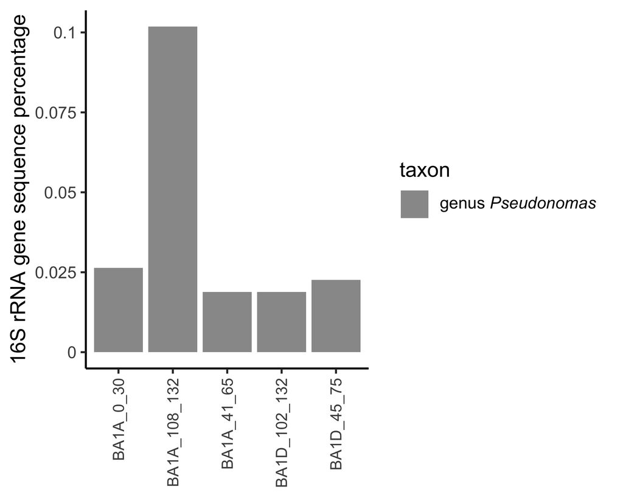

```r
# create plot
OM19_SCA_taxa_bar <- gathered_w_map_SCA %>% ggplot(

  # plot data
  aes(x = well,
      y = rel_abund,
      fill = tax_short)) +
  geom_bar(stat = "identity") +

  # axis styling
  scale_y_continuous(name = "16S rRNA gene sequence percentage", labels = formatter100)+
  scale_x_discrete(name = NULL)+

  # symbol styling
  scale_fill_manual(name = "taxon", values = cbPalette, labels = unname(latex2exp::TeX(c(
  "genus \\textit{Pseudonomas}")))) +

  # design
  theme_classic(base_size = 12)+
  theme(
    axis.text.x = element_text(angle = 90, hjust = 1, vjust = 0.5, size = 9),
    legend.direction = "vertical",
    legend.text.align = 0
)

# print
OM19_SCA_taxa_bar
```